# Actividad física y nutrición de los estudiantes de la UTEC durante la pandemia por covid-19 en el ciclo académico 2021.1

# I. Introducción

La pandemia por covid-19 que empezó a inicios del 2020 ha cambiado la rutina de casi todos los peruanos. La mayoría de los ciudadanos se han visto forzados a ha seguir leyes estrictas de confinamiento. Tanto el trabajo y la educación, como el deporte y la vida social, han sido presionados para caber dentro de las cuatro paredes de una pequeña habitación.

Específicamente, el cambio de rutina de los estudiantes peruanos ha sido significativo. Muchas actividades, producto de la asistencia física a la institución, han sido intercambiadas o, incluso, algunas, erradicadas. Entre estas, se pueden señalar tres. Primero, está el lugar de alimentación. La necesidad de permanecer en el centro durante horas de desayuno, almuerzo o cena, obligaba a muchos estudiantes a comer dentro o cerca del edificio. En este último año y medio, los alumnos se han visto forzados a comer en otro lugar. Segundo, se puede resaltar el traslado; ya sea a pie, bicicleta, carro, autobús o una combinación, ya no son demandados ni para acceder al lugar, ni para retornar de este, incluso, ya no es necesario que el sujeto en cuestión se desplace de clase en clase. Tercero, la cercanía física constante a otros individuos, profesores o compañeros, se extinguió; ahora, el canal de socialización con estos actores se redujo a la cámara y micrófono de un dispositivo con conexión a Internet.

La alteración radical del orden durante más de un año, nos hace cuestionar el estado actual de los alumnos de la Universidad de Ingeniería y Tecnología de Barranco, Lima. Por ello, en este estudio buscamos determinar si la rutina física y nutricional durante la pandemia tiene un impacto negativo en la salud de los estudiantes de la UTEC en base al IMC.

# II. Relevancia

El IMC es un indicador potencialmente útil para analizar la salud de las personas **(Nuttall, 2015)**. Idealmente, este trabajo podrá brindar información que contribuya a poner en mejor perspectiva el estado de salud actual de los alumnos de la UTEC. Tanto como un indicador para las autoridades de esta universidad, como un registro para futuros estudios relacionados con la nutrición y sedentarismo en pandemia, este trabajo podría ser pertinente.

# III. Plan de trabajo

| Tarea | 4 | 5 | 6 | 7 | 8 | 9 | 10 | 11 | 12 | 13 | 14 | 15 | 16 |
| --- | --- | --- | --- | --- | --- | --- | --- | --- | --- | --- | --- | --- | --- |
| Diseñar el estudio | 4 |  |  |  |  |  |  |  |  |  |  |  |  |
| Recolectar datos | 4 |  |  |  |  |  |  |  |  |  |  |  |  |
| Limpieza de datos | 4 | 5 |  |  |  |  |  |  |  |  |  |  |  |
| Análisis descriptivo | 4 | 5 |  |  |  |  |  |  |  |  |  |  |  |
| Distribución del IMC según otras variables |  | 5 |  |  |  |  |  |  |  |  |  |  |  |
| Correlación del IMC con otras variables |  | 5 |  |  |  |  |  |  |  |  |  |  |  |
| Redacción de la P1 | 4 | 5 |  |  |  |  |  |  |  |  |  |  |  |
| Correcciones de la P1 |  |  | 6 | 7 |  |  |  |  |  |  |  |  |  |
| Recategorización del IMC |  |  |  | 7 |  |  |  |  |  |  |  |  |  |
| Frecuencia según rango de IMC |  |  |  | 7 |  |  |  |  |  |  |  |  |  |
| Análisis probabilístico |  |  |  | 7 |  |  |  |  |  |  |  |  |  |
| Redacción de la P2 |  |  |  | 7 |  |  |  |  |  |  |  |  |  |
| Correcciones de la P2 |  |  |  |  |  | 9 |  |  |  |  |  |  |  |
| Uso de más modelos probabilísticos |  |  |  |  |  | 9 |  |  |  |  |  |  |  |
| Determinar la fiabilidad |  |  |  |  |  | 9 | 10 | 11 |  |  |  |  |  |
| Determinar la interferencia |  |  |  |  |  | 9 | 10 | 11 |  |  |  |  |  |
| Validar hipótesis |  |  |  |  |  |  | 10 | 11 |  |  |  |  |  |
| Redacción de la P3 |  |  |  |  |  | 9 | 10 | 11 |  |  |  |  |  |
| Correcciones de la P3 |  |  |  |  |  |  |  |  | 12 | 13 |  |  |  |
| Determinar capacidad predictiva |  |  |  |  |  |  |  |  | 12 | 13 | 14 |  |  |
| Revalidar hipótesis |  |  |  |  |  |  |  |  |  | 13 | 14 |  |  |
| Redacción de la P4 |  |  |  |  |  |  |  |  |  | 13 | 14 |  |  |

A continuación, se podrá ver una pequeña descripción de cada etapa.

### III.I. Diseño del estudio

En la primera etapa, se definirá la población, la muestra, el método de muestreo, las variables del estudio y la herramienta para recolección de datos.

### III.II. Carga y preprocesamiento de los datos

En la segunda etapa, se cargarán los datos descargados de Google Forms y se pondrán en el formato correcto.

### III.III. Distribución de cada variable

En la tercera etapa, se analizará de manera descriptiva cada variable. Se determinará qué datos tienen una variabilidad lo suficientemente alta como para ser usados posteriormente. Para ello, se verán las medidas de tendencia central de las variables numéricas y se verán los porcentajes de las variables categóricas.

### III.IV. Relación de las variables con el IMC

En la cuarta etapa, se verificará si existe una relación lineal, o “evidente”, de cada variable pertinente (seleccionadas en la etapa anterior) con el IMC. Para ello, se verán las medidas de tendencia central del IMC según cada nivel de las variables categóricas y se verán los grados de correlación del IMC con las variables numéricas. Asimismo, se verá la distribución de las variables categóricas según ciertos rangos del IMC. Posteriormente, se realizará un cálculo probabilístico para determinar la repercusión de cada subconjunto.

### III.V. Aleatoriedad y Fiabilidad

En la quinta etapa, se analizará la aleatoriedad y fiabilidad de los resultados. Dependiendo de aquello, se analizará la hipótesis: si la actividad física y la nutrición actual guarda una relación con en el IMC.

### III.VI. Predictabilidad

# IV. Diseño

## IV.I. Población y muestra

La población de la investigación son los estudiantes de la Universidad de Ingeniería y Tecnología de Barranco, Lima. De este grupo, se seleccionó una muestra de 163 observaciones por, principalmente, conveniencia.

### IV.I.I. Método de muestreo

El diseño del muestreo está dividido en 2 grandes partes: una centrada en recopilar la mayor cantidad de observaciones en el menor tiempo posible y otra centrada en aumentar la representatividad de las observaciones.

#### IV.I.I.I. Método para incrementar cantidad de observaciones

Con el fin de recopilar más datos, se les ofreció a los invitados la posibilidad de ganar S/50 mediante un sorteo en caso de participar.

#### IV.I.I.II. Métodos para incrementar la representatividad

Primero, se envió a 50 alumnos, seleccionados de manera aleatoria, un correo de invitación al estudio. Para ello, se implementó un programa en Python que generara una vocal y una consonante, o una consonante y una vocal, de manera aleatoria, 50 veces. Dichos resultados se utilizaron para que Gmail mostrara un subconjunto de los miembros de la universidad que cumplían con las primeras letras correspondientes. De esas opciones, se optó por el primer correo en cumplir tres condiciones: si es del dominio de la UTEC (utec.edu.pe), si es un alumno (“nombre.apellido”, no “napellido”) y si es alguien a quien no se le había escrito antes.

No se envió más de 50 correos para evitar romper potenciales políticas de la universidad relacionadas al envío masivo de mensajes a las cuentas institucionales.

Segundo, se seleccionaron algunos grupos de WhatsApp/Telegram de cursos que corresponden a múltiples carreras. No obstante, es importante resaltar que no se seleccionó aleatoriamente dicho subconjunto de cursos de todos los cursos de la universidad, sino solo de los que se tiene acceso: los cursos de múltiples carreras que llevan los integrantes del equipo de investigación.

| Curso | Ciclo mínimo |
| --- | --- |
| Estadística | 3 |
| English for STEAM | 4 |
| Matemáticas III | 3 |
| Investigación de Operaciones I | 4 |
| Seguridad y Salud | 4 |
| Termodinámica | 3 |
| Gestión de Empresas | 3 |
| Perú: ¿País Industrial? | 3 |

Tercero, por la baja representatividad de los ciclos 1 y 2, se optó por enviar la invitación a dos grupos de WhatsApp de estudiantes de primer ciclo: “Comunidad I+ UTEC” y “Comunidad I+ UTEC 2”.

Cuarto, por la potencialmente baja representatividad de los estudiantes de ciclos de 4 en adelante, se decidió enviar la invitación a tres grupos de carreras (que cuentan con alumnos de todos los ciclos): Bioingeniería, Ingeniería Civil y Ciencias de la Computación.

## IV.II. Medio de recolección de datos

Se decidió emplear encuestas con Google Forms para recopilar la información de los participantes.

Con el fin de asegurar la veracidad y procedencia de los datos, se restringió el acceso a la encuesta a los usuarios que cumplen con dos requisitos: tener una cuenta de Google que pertenece al dominio de la UTEC y no haber llenado la encuesta previamente con dicha cuenta.

## IV.III. Variables

Se dividió las variables en cuatro grupos: datos generales, actividad física, nutrición y autopercepción.

Es imperativo señalar que todas las preguntas, y las variables que derivan de estas, están situadas en en ciclo actual, 2021.1.

### IV.III.I. Variables sobre datos generales

#### IV.III.I.I. Variables numéricas sobre datos generales

| Pregunta | Variable | Unidad | Tipo | Restricción |
| --- | --- | --- | --- | --- |
| Edad | Edad | Años cumplidos | Discreta | Número entero positivo |
| Estatura en cm | Estatura | Centímetros | Continua | Número positivo |
| Peso en kg | Peso | Kilogramos | Continua | Número positivo |

#### IV.III.I.II. Variables categóricas sobre datos generales

| Pregunta | Variable | Tipo | Restricción |
| --- | --- | --- | --- |
| Sexo | Sexo | Nominal | Masculino o Femenino |
| ¿Dónde nació? | Procedencia | Nominal | Lima, Provincia o Extranjero |
| Actualmente, ¿dónde vive? | Residencia | Nominal | Lima, Provincia o Extranjero |
| Carrera en la UTEC | Carrera | Nominal | Una de las doce carreras de la UTEC |
| Ciclo en la UTEC | Ciclo | Ordinal | 1,2,3,4,5,6,7,8,9 o 10 |
| Escala en la UTEC | Escala | Ordinal | A,B,C,D o E |

### IV.III.II. Variables sobre actividad física

#### IV.III.II.I. Variables numéricas sobre actividad física

| Pregunta | Variable | Unidad | Tipo | Restricción |
| --- | --- | --- | --- | --- |
| ¿Cuántas horas dedica a realizar ejercicio cardiovascular/aeróbico a la semana? | Aeróbico | Horas/Semana | Discreta | Número entero positivo |
| ¿Cuántas horas dedica a realizar ejercicio anaeróbico a la semana? | Anaeróbico | Horas/Semana | Discreta | Número entero positivo |
| ¿Cuántas horas dedica a practicar un deporte a la semana? | Deporte | Horas/Semana | Discreta | Número entero positivo |
| ¿Cuántas horas dedica a ver servicios de streaming de video a la semana? | Video | Horas/Semana | Discreta | Número entero positivo |
| ¿Cuántas horas dedica a jugar videojuegos a la semana? | Videojuego | Horas/Semana | Discreta | Número entero positivo |
| ¿Cuántas horas dedica a las redes sociales a la semana? | RedSocial | Horas/Semana | Discreta | Número entero positivo |
| ¿Cuántas horas de clase tiene a la semana? | Clase | Horas/Semana | Discreta | Número entero positivo |
| ¿Cuántas horas dedica a estudiar y hacer trabajos para la universidad a la semana? (fuera de las clases) | Estudio | Horas/Semana | Discreta | Número entero positivo |
| ¿Cuántas horas trabaja remuneradamente a la semana? | Trabajo | Horas/Semana | Discreta | Número entero positivo |

#### IV.III.II.II. Variables categóricas sobre actividad física

| Pregunta | Variable | Tipo | Restricción |
| --- | --- | --- | --- |
| ¿Asiste a un gimnasio? | Gimnasio | Nominal | Sí o No |
| ¿Asiste a un club para ejercitarse físicamente? | Club | Nominal | Sí o No |
| Mayormente, cuando trabaja remuneradamente, ¿su cuerpo se mueve de manera considerable? | TrabajoMovil | Nominal | Sí o No |

### IV.III.III. Variables sobre nutrición

#### IV.III.III.I. Variables numéricas sobre nutrición

| Pregunta | Variable | Unidad | Tipo | Restricción |
| --- | --- | --- | --- | --- |
| ¿Cuántas veces desayuna a la semana? | Desayuno | Veces/Semana | Discreta | Número entero positivo del 0 al 7 |
| ¿Cuántas veces almuerza a la semana? | Almuerzo | Veces/Semana | Discreta | Número entero positivo del 0 al 7 |
| ¿Cuántas veces cena a la semana? | Cena | Veces/Semana | Discreta | Número entero positivo del 0 al 7 |
| ¿Cuántas veces come fruta a la semana? | Fruta | Veces/Semana | Discreta | Número entero positivo |
| Al día, ¿cuántas veces come pickeos entre comidas? (galletas, chips, maní, etc) | Pickeo | Veces/Día | Discreta | Número entero positivo |
| ¿Cuántas veces pide delivery para comer a la semana? | Delivery | Veces/Semana | Discreta | Número entero positivo |

#### IV.III.III.II. Variables categóricas sobre nutrición

| Pregunta | Variable | Tipo | Restricción |
| --- | --- | --- | --- |
| Usualmente, la relación entre los carbohidratos y proteínas en su plato se asemeja a… | CarboProte | Nominal | Más carbohidratos, Más proteínas o Casi igual cantidad |
| Usualmente, la relación entre los vegetales y todo lo demás (carbohidratos + proteínas) en su plato se asemeja a… | Vegetal | Ordinal | Más vegetales, Casi igual cantidad, Menos vegetales, No suelo comer vegetales |

### IV.III.IV. Variables sobre autopercepción

#### IV.III.IV.I. Variables categóricas sobre autopercepción

| Pregunta | Variable | Tipo | Restricción |
| --- | --- | --- | --- |
| ¿Cómo calificaría su actividad física? | Físico | Ordinal | Excelente, Bueno, Regular, Malo o Desastroso |
| ¿Cómo calificaría su nutrición? | Nutrición | Ordinal | Excelente, Bueno, Regular, Malo o Desastroso |
| ¿Cómo calificaría su rendimiento académico? | Académico | Ordinal | Excelente, Bueno, Regular, Malo o Desastroso |

# V. Carga y preprocesamiento de los datos

```r
library(readr)
library(dplyr)
library(lessR)
round2 = function(x) round(x, digits = 2)
ordenar.ordinal = function(ordinal, orden) factor(as.factor(ordinal), levels = orden)

df = read_csv("ProyectoDF.csv")
df$Videojuego = as.numeric(df$Videojuego)
df$Sexo = as.factor(df$Sexo)
df$Procedencia = as.factor(df$Procedencia)
df$Residencia = as.factor(df$Residencia)
df$CompanerosVivienda = as.factor(df$CompanerosVivienda)
df$Ciclo = ordenar.ordinal(df$Ciclo)
df$Escala = ordenar.ordinal(df$Escala)
df$Carrera = as.factor(df$Carrera)
df$Club = as.factor(df$Club)
df$Gimnasio = as.factor(df$Gimnasio)
df$TrabajoMovil = as.factor(df$TrabajoMovil)
df$CarboProte = as.factor(df$CarboProte)
df$Vegetal = ordenar.ordinal(df$Vegetal, c("No suelo comer vegetales", "Menos vegetales", "Casi igual cantidad","Más vegetales"))
df$Fisico  = ordenar.ordinal(df$Fisico, c("Desastroso", "Malo", "Regular", "Bueno", "Excelente"))
df$Nutricion = ordenar.ordinal(df$Nutricion, c("Desastroso", "Malo", "Regular", "Bueno", "Excelente"))
df$Animos = as.factor(df$Animos)
df$Academico  = ordenar.ordinal(df$Academico, c("Malo", "Regular", "Bueno", "Excelente"))
```

# VI. Distribución de cada variable

En esta sección, se analizará de manera descriptiva un subconjunto de las variables con el fin de poder entrar a mayor detalle sin aumentar considerablemente la extensión del informe. Por un lado, se optó por hacer tablas que resuman la distribución de las variable numéricas, en lugar de un gráfico para cada una. Por el otro lado, las variable categóricas se graficaron como un diagrama de barras de frecuencias que muestran tanto el valor absoluto como el porcentaje.

Es importante notar que **después** de cada tabla o gráfico hay uno o varios párrafos de análisis. En aquella parte, se mencionará las principales conclusiones sobre la distribución de cada variable.

Asimismo, es indispensable detallar la utilidad de la columna “Atípicos” de las tablas de resumen: son tuplas que indican que porcentaje del total son valores atípicos pequeños y que porcentaje del total son valores atípicos grandes. Se considera más ilustrativo que contar con la frecuencia absoluta de atípicos.

Por último, se debe de resaltar que, en los resúmenes, la media es acompañada por un intervalo de confianza del 95%. Si se repite el experimento, se espera que el 95% de las veces la media se encuentre entre el rango mostrado. Se optó por 95%, y no un valor menor, porque se busca que el verdadero promedio de la población se encuentre dentro de lo calculado.

```r
#Utilidad
make.interval = function(center, error) c(center-error, center+error)
round.interval = function(interval, digits) c(floor((10^digits)*interval[1])/(10^digits), ceiling((10^digits)*interval[2])/(10^digits))
text.interval = function(interval) paste("(", interval[1], ",", interval[2], ")")

#Probabilidad
pmean = function(x, mu, s, n) pnorm(x, mu, s/sqrt(n))
pprop = function(p, mu, n) pnorm(p, mu, sqrt(p*(1-p)/n))

#Error
emean = function(s, n, conf, real.s = FALSE) ifelse(n<30 & !real.s, qt(1-((1-conf)/2), n-1), qnorm(1-((1-conf)/2)))*s/sqrt(n)
eprop = function(p, n, conf) qnorm(1-((1-conf)/2))*sqrt(p*(1-p)/n)

#Intervalo
imean = function(x, s, n, conf, real.s = FALSE) round.interval(make.interval(x, emean(s, n, conf, real.s)), 2)
iprop = function(p, n, conf) round.interval(make.interval(p, eprop(p, n, conf)), 2)

#Tamaño de muestra
nmean = function(s, conf, error) ceiling((qnorm(1-((1-conf)/2))*s/error)^2)
nprop = function(conf, error) ceiling((qnorm(1-((1-conf)/2))/(2*error))^2)

#Confianza
cmean = function(s, n, error) round(1+2*(pnorm(error*sqrt(n)/s)-1), 2)
cprop = function(n, error) round(1+2*(pnorm(error*2*sqrt(n))-1), 2)

#Resumen
resumen.numerico = function(numericas){
resumen = data.frame(
  "Rango" = apply(numericas, 2, function(x)paste("(", min(x), ",", max(x), ")")),
  "Media.95conf" = apply(numericas, 2, function(x)paste(round2(mean(x)), text.interval(imean(mean(x), sd(x), length(x), 0.95)))),
  "Mediana.IQR" = apply(numericas, 2, function(x)paste(median(x), "(", quantile(x, 0.25), ",", quantile(x, 0.75), ")")),
  "Atípicos" = apply(numericas, 2, function(x) paste("(", round(sum(x<(quantile(x, 0.25) - IQR(x)*1.5))*100/length(x)), "% , ", round(sum(x>(quantile(x, 0.75) + IQR(x)*1.5))*100/length(x)), "% )")),
  "SD" = apply(numericas, 2, function(x) paste(round2(sd(x)))),
  "Sesgo" = apply(numericas, 2, function(x)if(mean(x)<median(x)) "Negativo" else if(mean(x)>median(x)) "Positivo" else "Ninguno")
)
resumen
}


resumen.categorico = function(...){
  style(quiet=TRUE)
  BarChart(..., data=df, fill="darkblue", color="black", trans=.8, values_color="black", rotate_x=45, ylab="Cantidad", main=paste("Distribución de la variable ", deparse(substitute(...))))
}

#Comparación con modelos
comparar.modelo.continuo = function(continua, nombre, modelo, leyenda.modelo, altura){
  curve(modelo(x), from=min(continua), to=max(continua), lwd=2, lty="dotted", ylab="Densidad", xlab=nombre, col="red", ylim=c(0, altura))
lines(density(continua), col="blue", lwd=2)
legend('topright', legend=c(nombre, leyenda.modelo),
       col=c("blue", "red"), lty=1:2, cex=0.8)
}
comparar.normal = function(continua, nombre, altura) comparar.modelo.continuo(continua, nombre, function(x) dnorm(x, mean(continua), sd(continua)), paste("Norm(", round(mean(continua), 1), ",", round(sd(continua), 1), ")"), altura)

comparar.exponencial = function(continua, nombre, altura) comparar.modelo.continuo(continua, nombre, function(x) dexp(x, 1/mean(continua)), paste("Exp( 1 /", round(mean(continua), 2), ")"), altura)

comparar.modelo.discreto = function(discreta, nombre, modelo, leyenda.modelo, altura){
  hist(discreta, prob=TRUE, ylab="Densidad", xlab=nombre, breaks=((min(discreta):(max(discreta)+1))-0.5), ylim=c(0, altura), main="")
  points(min(discreta):max(discreta), modelo(min(discreta):max(discreta)), col="red", pch=20, type="h", lwd = 3, lty = 2)
  legend('topright', legend=c(leyenda.modelo),
       col=c("red"), lty=2, cex=0.8)
}

comparar.geometrica = function(discreta, nombre, altura) comparar.modelo.discreto(discreta, nombre, function(x) dgeom(x, 1/mean(discreta)), paste("Geom( 1 /", round(mean(discreta), 2), ")"), altura)

#Proporciones
proporciones = function(contable, nombre) knitr::kable(data.frame(
  "Prop.95conf" = apply((Vectorize(iprop, c("p"))(table(contable)/length(contable), length(contable), 0.95)), 2, text.interval)
), captio=nombre)
```

## VI.I. Distribución de cada variable sobre datos generales

### VI.I.I. Distribución de cada variable numérica sobre datos generales

En esta sección, se puede observar, a grandes rasgos, la distribución de la edad, estatura y peso.

```r
resumen.numerico(select(df, Edad, Estatura, Peso))
```

|  | Rango | Media.95conf | Mediana.IQR | Atípicos | SD | Sesgo |
| --- | --- | --- | --- | --- | --- | --- |
| Edad | ( 16 , 26 ) | 18.95 ( 18.67 , 19.23 ) | 19 ( 18 , 20 ) | ( 0 % , 1 % ) | 1.79 | Negativo |
| Estatura | ( 150 , 194 ) | 169.61 ( 168.24 , 170.99 ) | 170 ( 163.5 , 176 ) | ( 0 % , 0 % ) | 8.92 | Negativo |
| Peso | ( 40 , 105 ) | 67.37 ( 65.41 , 69.34 ) | 65 ( 58 , 75 ) | ( 0 % , 1 % ) | 12.79 | Positivo |

En cuanto a la edad, se pueden identificar 3 características de la muestra. Primero, la gran mayoría de los estudiantes están entre los 18 y 20 años, indicado por los cuartiles. Segundo, la distribución es cercana a simétrica, pues la media y la mediana son casi iguales y existe una ínfima cantidad de valores atípicos. Tercero, existen más alumnos menores a 18 que mayores a 20, pues, a pesar de haber alumnos con 26 años de edad, la media es menor a la mediana.

En cuanto a la estatura, se pueden identificar 2 características. Primero, la gran mayoría de los estudiantes miden entre 163.5 y 176 centímetros, indicado por los cuartiles. Segundo, la distribución es simétrica (distribución normal), pues la media y la mediana son casi iguales y no existen valores atípicos.

En cuanto al peso, se pueden identificar 3 características. Primero, la gran mayoría de los estudiantes pesan entre 58 y 75 kilogramos, indicado por los cuartiles. Segundo, la distribución es cercana a simétrica, pero no tan simétrica como la estatura, pues la diferencia entre la media y la mediana es mayor en proporción y, además, aunque muy pocos, existen casos atípicos. Tercero, los casos más alejados del común son estudiantes con pesos superiores a 75 kilogramos, pues la diferencia entre el menor caso (40kg) y el promedio (mediana o media) es menor a la diferencia entre el mayor caso (105kg) y el promedio.

A continuación, se puede observar la gráfica de densidad de la variable estatura. Como se mencionó, debido a la cercanía de la media y la mediana, se asemeja a una distribución normal. En este caso, la distribución normal estaría conformada con un promedio de 169 y desviación estándar 8.9. Entre las principales diferencias está el desface entre los picos de las distribuciones y un mayor número de personas bajas en el caso de la distribución de real de la muestra. **A pesar de ello, en términos generales, la gráfica de densidad señala que a mayor distancia de la media (169.6), la frecuencia disminuye aún más, especialmente para los casos de mayor estatura.**

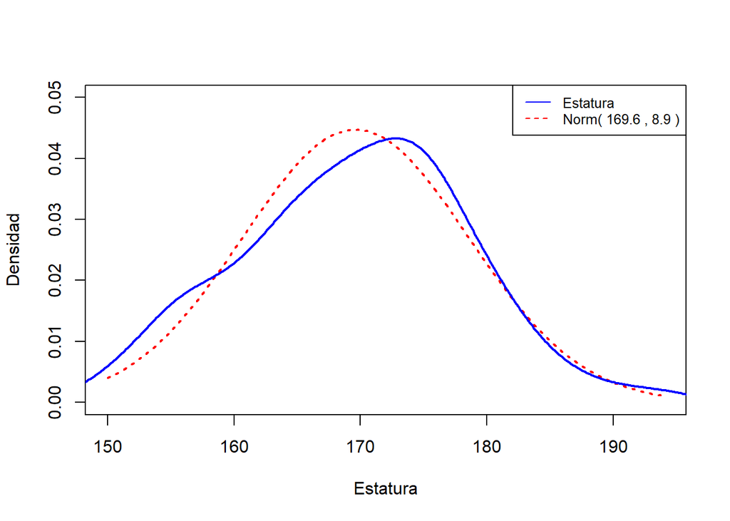

```r
comparar.normal(df$Estatura, "Estatura", 0.05)
```

### VI.I.II. Distribución de cada variable categórica sobre datos generales

#### VI.I.II.I. Distribución del sexo

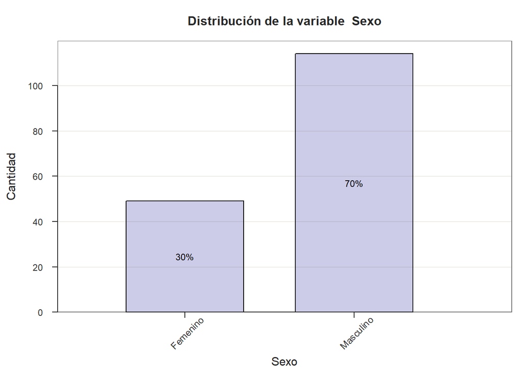

```r
resumen.categorico(Sexo)
```

En cuanto al sexo, se puede observar que hay más del doble de hombres que de mujeres en la muestra. En un contexto genérico, esta variable parece no ser representativa, pues se esperaría una proporción similar de hombres que de mujeres (~50%). No obstante, si se considera el escenario específico de la UTEC, no sería irracional formular la siguiente **hipótesis: estudiar en la UTEC está relacionado con el sexo de la persona.**

```r
proporciones(df$Sexo, "Sexo")
```

Sexo

|  | Prop.95conf |
| --- | --- |
| Femenino | ( 0.23 , 0.38 ) |
| Masculino | ( 0.62 , 0.77 ) |

Se puede observar que con un **intervalo de confianza del 95%** dichas proporciones se mantienen distantes del ~50% esperado. La posible relación entre el sexo, las actividades y el físico de una persona, nos dan las razones suficientes para investigar esta teoría sobre la distribución del sexo en la UTEC. Esto se verá en el apartado de pruebas de hipótesis.

En caso de ser válida la hipótesis y representativa la muestra, se puede visualizar la probabilidad de escoger aleatoriamente un hombre estudiante de la UTEC como una variable que sigue la **distribución de Bernoulli**. Donde obtener un hombre es el éxito, con una probabilidad del 70%, y no obtener un hombre (una mujer) es el fracaso, con una probabilidad del 30%. Así, si se volvería a repetir el muestreo de 163 observaciones, la variable que cuenta el número de hombres seguiría una **distribución binomial B(163, 0.7)**.

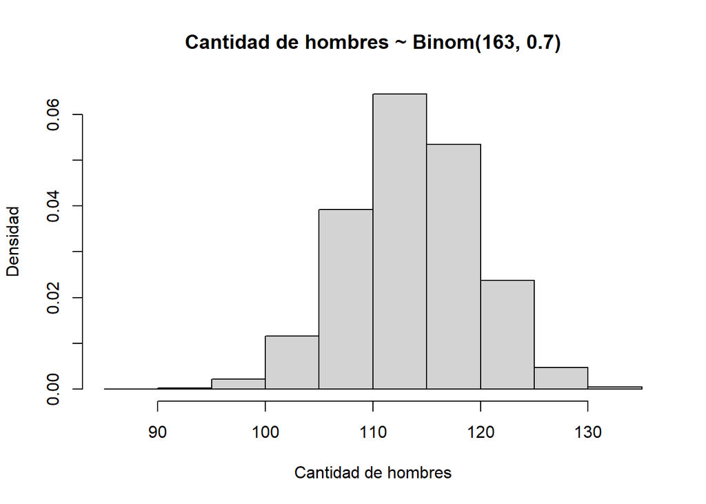

```r
hist(rbinom(10000, 163, 0.7), prob=TRUE, xlab="Cantidad de hombres", ylab="Densidad", main="Cantidad de hombres ~ Binom(163, 0.7)")
```

#### VI.I.II.II. Distribución de la carrera universitaria

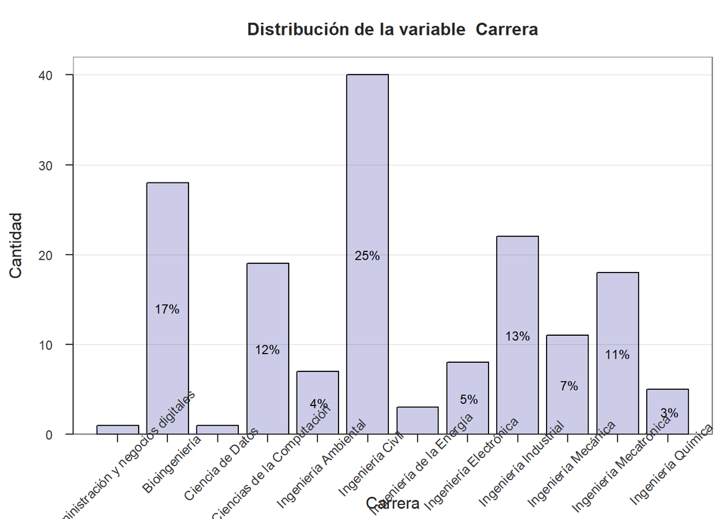

```r
resumen.categorico(Carrera)
```

A pesar de velar por el aumento de la representatividad y emplear múltiples técnicas para lograrlo (mencionado en la metodología de muestreo), en cuanto a la carrera universitaria, se pueden identificar 2 lamentables características. Primero, existe un claro sesgo de la carrera de Ingeniería Civil, la cual representa un cuarto de la muestra y es la moda por una gran diferencia; la segunda más frecuente (Bioingeniería) tiene ocho puntos porcentuales por debajo de aquella. Segundo, las dos carreras menos frecuentes son Administración y negocios digitales, y Ciencia de Datos. Estas dos carreras probablemente no estén tan “infrarepresentadas”, pues las dos son carreras nuevas.

#### VI.I.II.III. Distribución de la escala universitaria

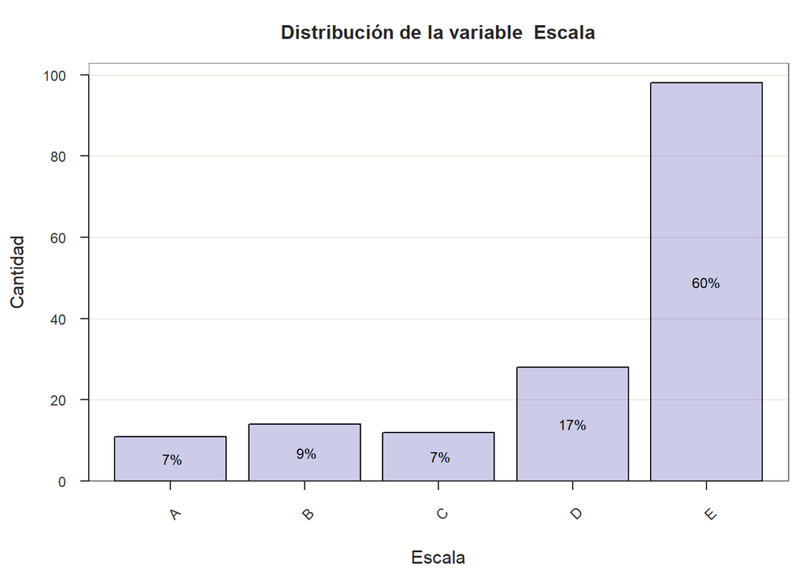

```r
resumen.categorico(Escala)
```

En cuanto a la escala en la universidad, se pueden identificar 2 características. Primero, la escala E, sola, representa más de la mitad de la muestra. Segundo, ninguna de las demás escalas tiene una diferencia tan marcada como con la escala E.

Estas características probablemente reflejen, en cierta medida, la distribución real de las escalas en la UTEC. Sin embargo, es importante resaltar un sesgo en la modalidad de recolección de datos (mencionado en la metodología de muestreo): con el fin de aumentar la cantidad de observaciones en un tiempo corto, se motivó la participación de los alumnos con la promesa de un sorteo de cincuenta soles peruanos. El interés por el sorteo, y por ende, de participar en el estudio, podría guardar una relación con la situación económica del individuo. Es decir, probablemente, hay mucho más alumnos de la categoría E, porque pudieron estar más motivados en participar que los alumnos, por ejemplo, de la categoría A.

## VI.II. Distribución de cada variable sobre actividad física

### VI.II.I. Distribución de cada variable numérica sobre actividad física

En esta sección, se puede observar, a grandes rasgos, la distribución de la cantidad de ejercicio, ya sea aeróbico, anaeróbico o deporte, que realiza el estudiante.

#### VI.II.I.I. Distribución de actividades que implican ejercicio físico

```r
resumen.numerico(select(df, Aerobico, Anaerobico, Deporte))
```

|  | Rango | Media.95conf | Mediana.IQR | Atípicos | SD | Sesgo |
| --- | --- | --- | --- | --- | --- | --- |
| Aerobico | ( 0 , 30 ) | 2.96 ( 2.29 , 3.64 ) | 2 ( 0 , 4 ) | ( 0 % , 3 % ) | 4.35 | Positivo |
| Anaerobico | ( 0 , 50 ) | 1.84 ( 1.17 , 2.51 ) | 1 ( 0 , 2.5 ) | ( 0 % , 4 % ) | 4.31 | Positivo |
| Deporte | ( 0 , 28 ) | 1.21 ( 0.7 , 1.73 ) | 0 ( 0 , 1 ) | ( 0 % , 15 % ) | 3.33 | Positivo |

En cuanto al ejercicio anaeróbico, se pueden identificar 3 características. Primero, el promedio de ejercicio anaeróbico gira entorno a 1 hora por semana. Segundo, no cuenta con una distribución simétrica, pues la media y la mediana difieren, y la desviación estándar es considerablemente alta (más del doble que la media). Tercero, todos los casos atípicos son estudiantes que se ejercitan bastante, no al revés.

En cuanto a la práctica de un deporte, se pueden identificar 3 características. Primero, el promedio de deporte gira entorno a 0 horas por semana. Segundo, no cuenta con una distribución simétrica, pues la media y la mediana difieren, la desviación estándar es considerablemente alta (más del doble que la media) y, además, casi un sexto de la muestra es atípica. Tercero, todos los casos atípicos son estudiantes que se ejercitan bastante, no al revés.

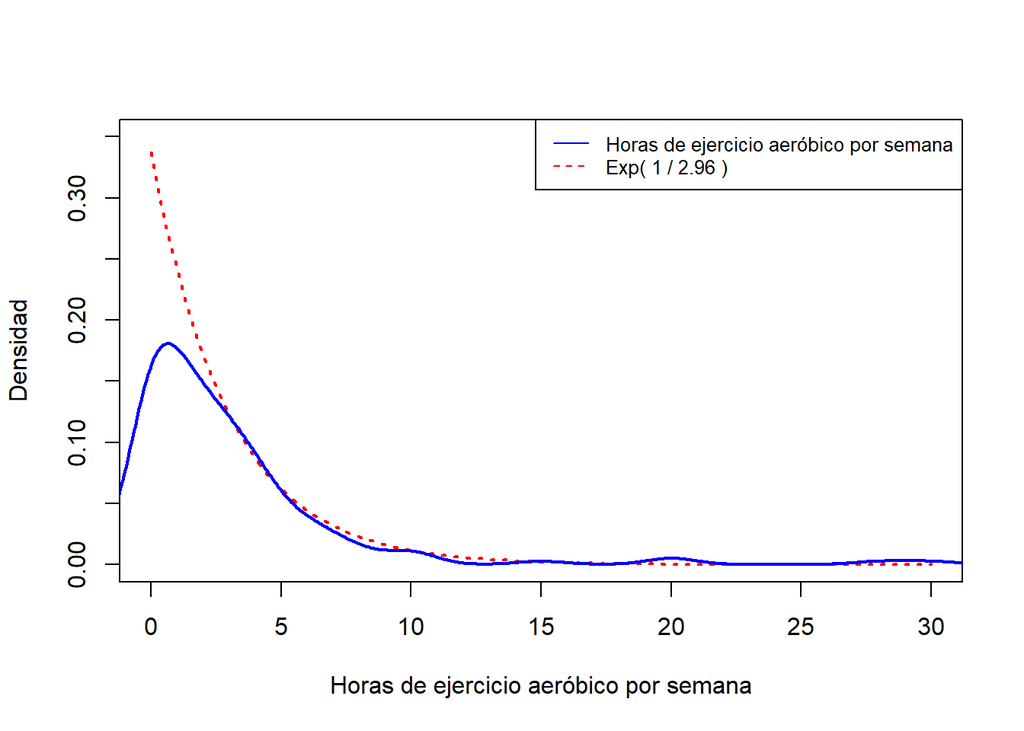

```r
comparar.exponencial(df$Aerobico, "Horas de ejercicio aeróbico por semana", 0.35)
```

#### VI.II.I.II. Distribución de actividades que implican no hacer ejercicio físico.

```r
resumen.numerico(select(df,  Video, RedSocial, Clase))
```

|  | Rango | Media.95conf | Mediana.IQR | Atípicos | SD | Sesgo |
| --- | --- | --- | --- | --- | --- | --- |
| Video | ( 0 , 50 ) | 6.98 ( 5.87 , 8.09 ) | 5 ( 2 , 9 ) | ( 0 % , 6 % ) | 7.2 | Positivo |
| RedSocial | ( 0 , 50 ) | 8.66 ( 7.32 , 10.01 ) | 6 ( 3 , 10 ) | ( 0 % , 10 % ) | 8.74 | Positivo |
| Clase | ( 0 , 50 ) | 24.22 ( 22.95 , 25.49 ) | 25 ( 20 , 28 ) | ( 5 % , 2 % ) | 8.22 | Negativo |

En cuanto al consumo de videos por entretenimiento, se pueden identificar 3 características. Primero, el promedio de consumo de videos gira entorno a 5 horas por semana. Segundo, no cuenta con una distribución simétrica, pues la media y la mediana difieren, y la desviación estándar es considerablemente alta (casi igual a la media). Tercero, los casos atípicos son estudiantes que consumen bastante videos.

En cuanto al consumo de redes sociales, se pueden identificar 3 características. Primero, el promedio de consumo de redes sociales gira entorno a 6 horas por semana. Segundo, no cuenta con una distribución simétrica , pues la media y la mediana difieren, y la desviación estándar es considerablemente alta (casi igual a la media). Tercero, los casos atípicos son estudiantes que consumen bastante redes sociales.

En cuanto a las clases, se pueden identificar 3 características. Primero, el promedio de consumo de clases (virtuales) gira entorno a 25 horas por semana. Segundo, no cuenta con una distribución simétrica, pero tampoco cuenta con mucha asimetría, pues la media y la mediana no son tan diferentes y los casos atípicos se presentan en ambos extremos. Tercero, los casos atípicos de los estudiantes que consumen poca clases son más del doble de frecuentes que los casos atípicos de estudiantes que consumen muchas clases (5% vs 2%).

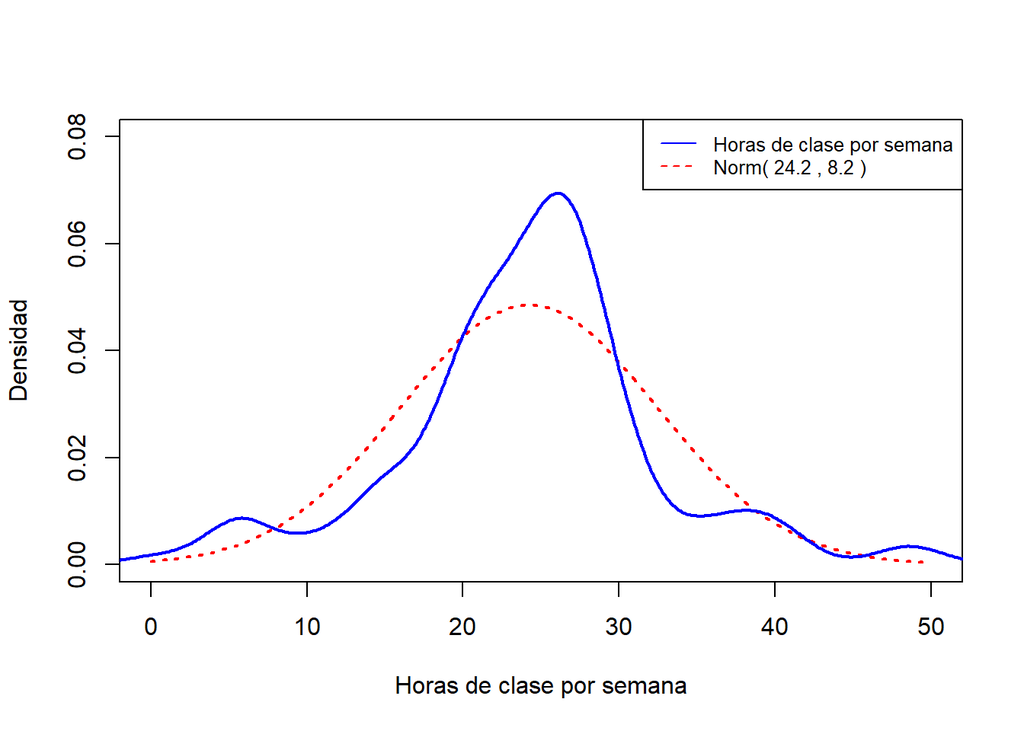

```r
comparar.normal(df$Clase, "Horas de clase por semana", 0.08)
```

## VI.III. Distribución de cada variable sobre nutrición

### VI.III.I. Distribución de cada variable numérica sobre nutrición

```r
resumen.numerico(select(df, Desayuno, Cena, Delivery, Pickeo))
```

|  | Rango | Media.95conf | Mediana.IQR | Atípicos | SD | Sesgo |
| --- | --- | --- | --- | --- | --- | --- |
| Desayuno | ( 0 , 7 ) | 6.28 ( 6.05 , 6.52 ) | 7 ( 6 , 7 ) | ( 10 % , 0 % ) | 1.49 | Negativo |
| Cena | ( 0 , 7 ) | 6.17 ( 5.94 , 6.39 ) | 7 ( 6 , 7 ) | ( 14 % , 0 % ) | 1.45 | Negativo |
| Delivery | ( 0 , 14 ) | 1.2 ( 0.95 , 1.46 ) | 1 ( 0 , 2 ) | ( 0 % , 1 % ) | 1.64 | Positivo |
| Pickeo | ( 0 , 7 ) | 1.33 ( 1.11 , 1.54 ) | 1 ( 0 , 2 ) | ( 0 % , 2 % ) | 1.39 | Positivo |

En cuanto al desayuno, se pueden identificar 3 características. Primero, la gran mayoría come desayuno 7 veces a la semana. Segundo, por lo menos un cuarto de los alumnos toman entre 0 y 6 veces desayuno. Tercero, los casos atípicos representan un décimo de la muestra y son los que comen pocas veces desayuno.

En cuanto al consumo de comida por delivery, se pueden identificar 2 características. Primero, el promedio de consumo de comida por delivery es de 1 vez a la semana. Segundo, hay una porción casi despreciable de casos atípicos (teniendo en cuenta el tamaño de la muestra) y estos son los que piden mucho delivery a la semana.

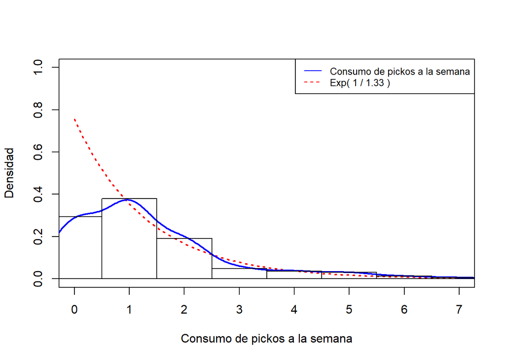

```r
comparar.exponencial(df$Pickeo, "Consumo de pickos a la semana", 1)
hist(df$Pickeo, col=rgb(0,0,0,alpha = 0), add=TRUE, prob=TRUE, breaks=(0:(max(df$Pickeo)+1))-0.5)
```

# VII. Relación de las variables con el IMC

En esta sección, se verificará si existe una relación “marcada” de cada variable con el IMC. Para ello, se verán las medidas de tendencia central del IMC según cada nivel de las variables categóricas y se verán los grados de correlación del IMC con las variables numéricas. Asimismo, en una tercera subsección, se verá la frecuencia de cada categoría según rangos del IMC.

Es importante notar que **antes** de cada subconjunto de gráficos hay un párrafo de análisis sobre dicha sección. En aquellas partes se discutirá si existe, con alguna de las variables, una aparente relación con el IMC y se formularán, en la medida de lo posible, hipótesis.

```r
#Funciones para la primera subsección
cajas = function(name, xlabel, ylabel, form, d){
  boxplot(form, data = d, main = name, xlab = xlabel, ylab = ylabel, notch = TRUE)
}

#Funciones para la segunda subsección
dispersionc = function(name, xlabel, ylabel, x, y, z, a = c("blue", "green", "purple", "orange", "brown", "yellow", "black", "cyan")){
  plot(x, y, col = a[z], main = paste(name, "(", round2(cor(x, y)), ")"), xlab = xlabel, ylab = ylabel, pch = 20)
  legend('topright', legend = levels(z), col = a, cex = 0.8, pch = 20)
  abline(lm(y ~ x), col = "red", lwd = 3)
}

dispersion = function(name, xlabel, ylabel, x, y){
  plot(x, y, main = name, xlab = xlabel, ylab = ylabel)
  abline(lm(y ~ x), col = "red", lwd = 3)
}

#Funciones para tercera subsección
IMC.segun = function(...)mosaicplot(table(select(df, c(...)[1], C.IMC)), main=paste("Diagnóstico según", c(...)[1]))
```

## VII.I. Distribución del IMC según variables categóricas

A continuación, se puede observar 9 gráficos de múltiples caja y bigotes. En esta subsección se busca determinar si alguna de las variables categóricas tiene un impacto en el IMC.

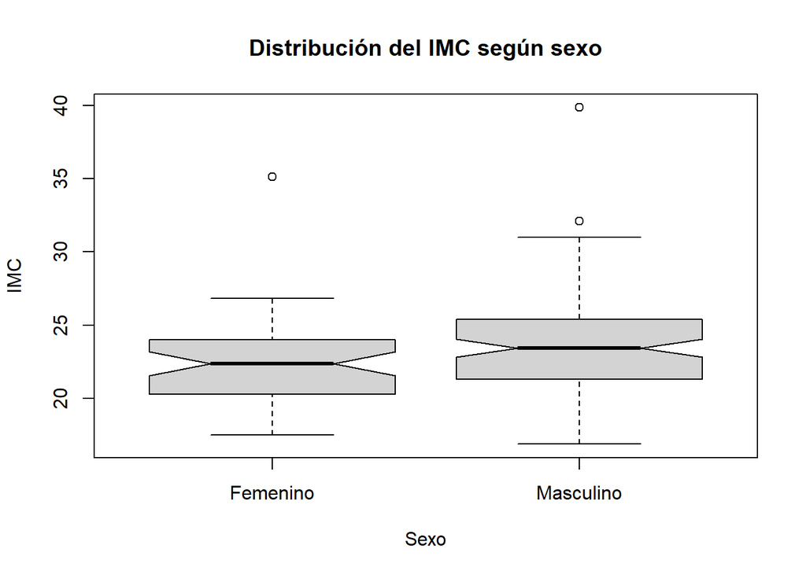

```r
df = transform(df, IMC = apply(select(df, Peso, Estatura), 1, function(x) x[1]/(x[2]/100)^2))
cajas("Distribución del IMC según sexo", "Sexo", "IMC", IMC~Sexo, df)
```

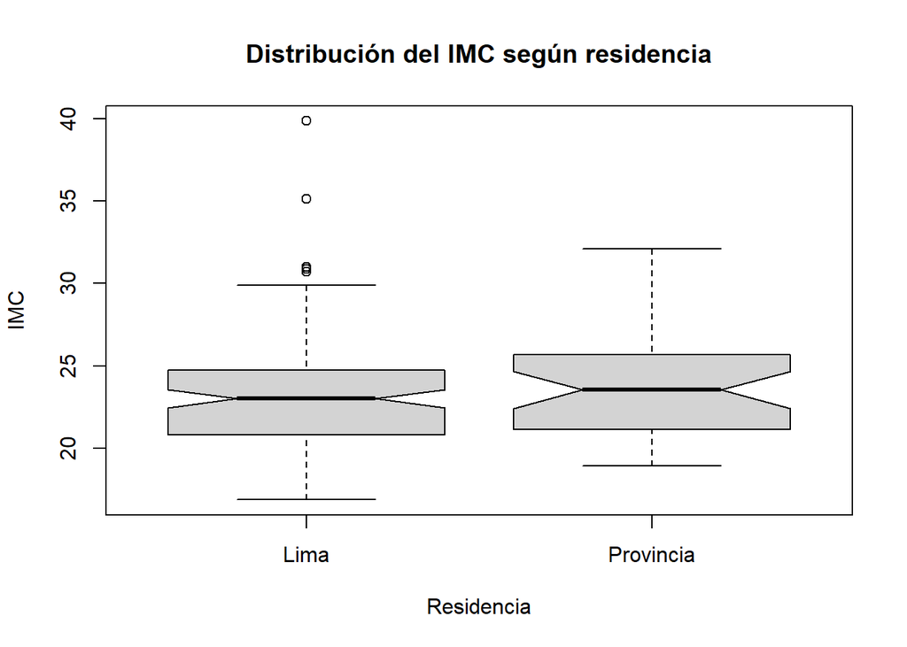

```r
cajas("Distribución del IMC según residencia", "Residencia", "IMC", IMC~Residencia, df)
```

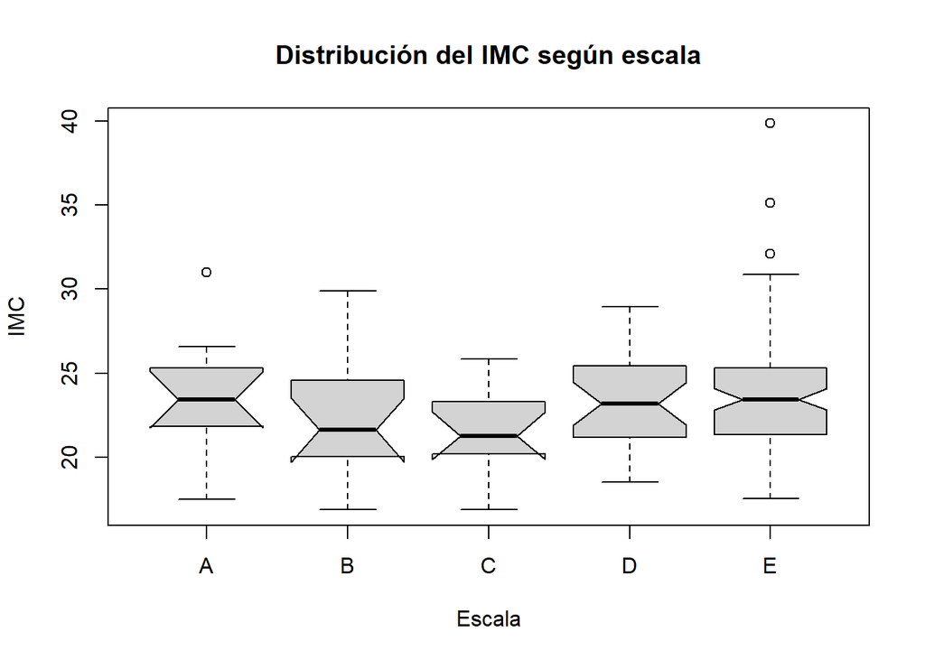

```r
cajas("Distribución del IMC según escala", "Escala", "IMC", IMC~Escala, df)
```

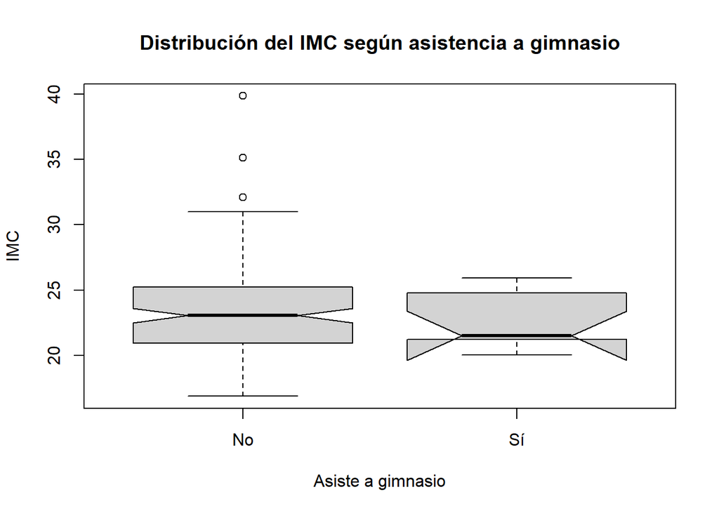

```r
cajas("Distribución del IMC según asistencia a gimnasio", "Asiste a gimnasio", "IMC", IMC~Gimnasio, df)
```

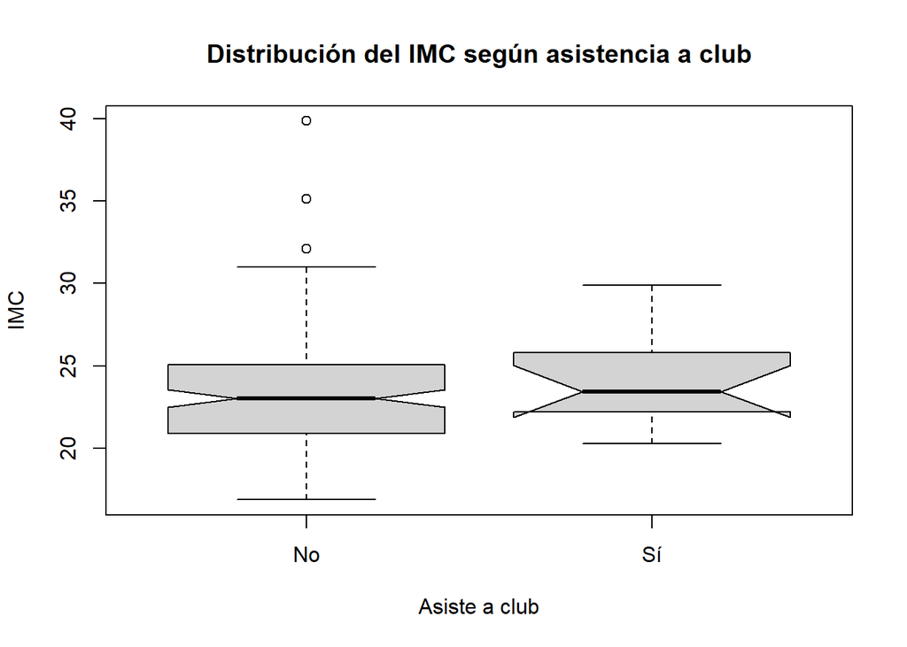

```r
cajas("Distribución del IMC según asistencia a club", "Asiste a club", "IMC", IMC~Club, df)
```

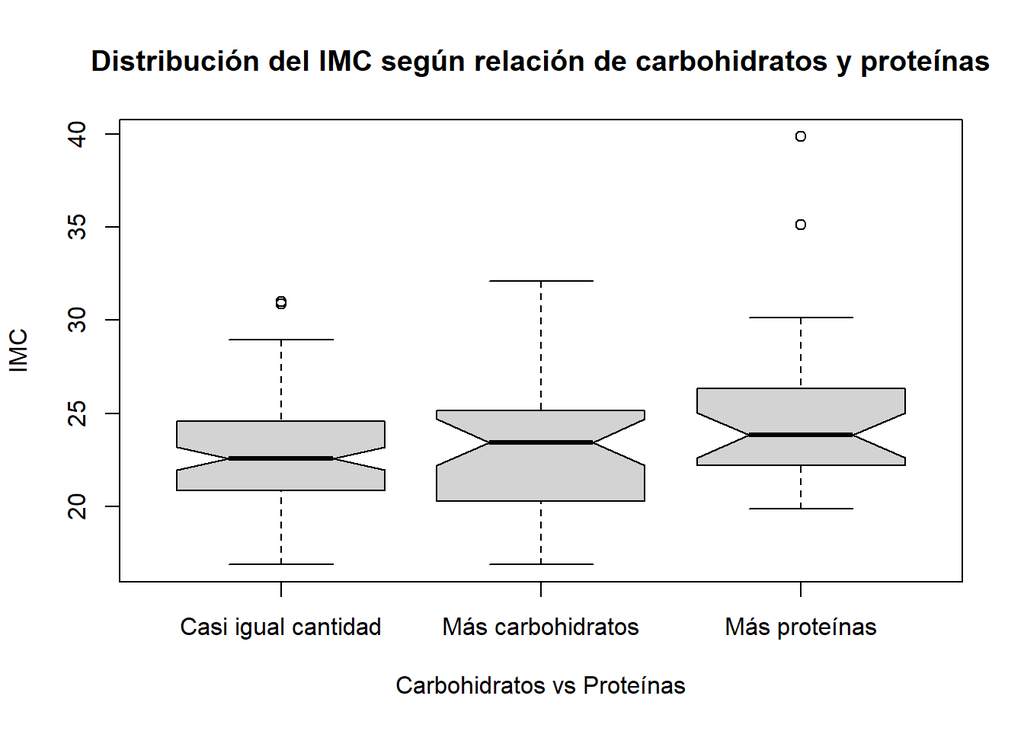

```r
cajas("Distribución del IMC según relación de carbohidratos y proteínas", "Carbohidratos vs Proteínas", "IMC", IMC~CarboProte, df)
```

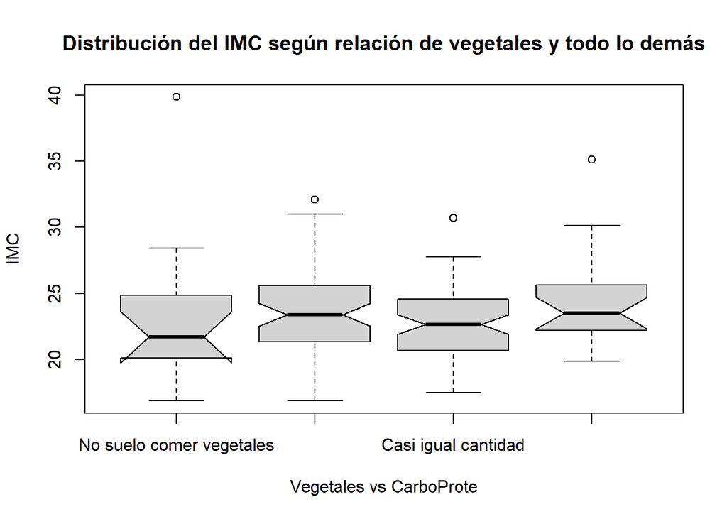

```r
cajas("Distribución del IMC según relación de vegetales y todo lo demás", "Vegetales vs CarboProte", "IMC", IMC~Vegetal, df)
```

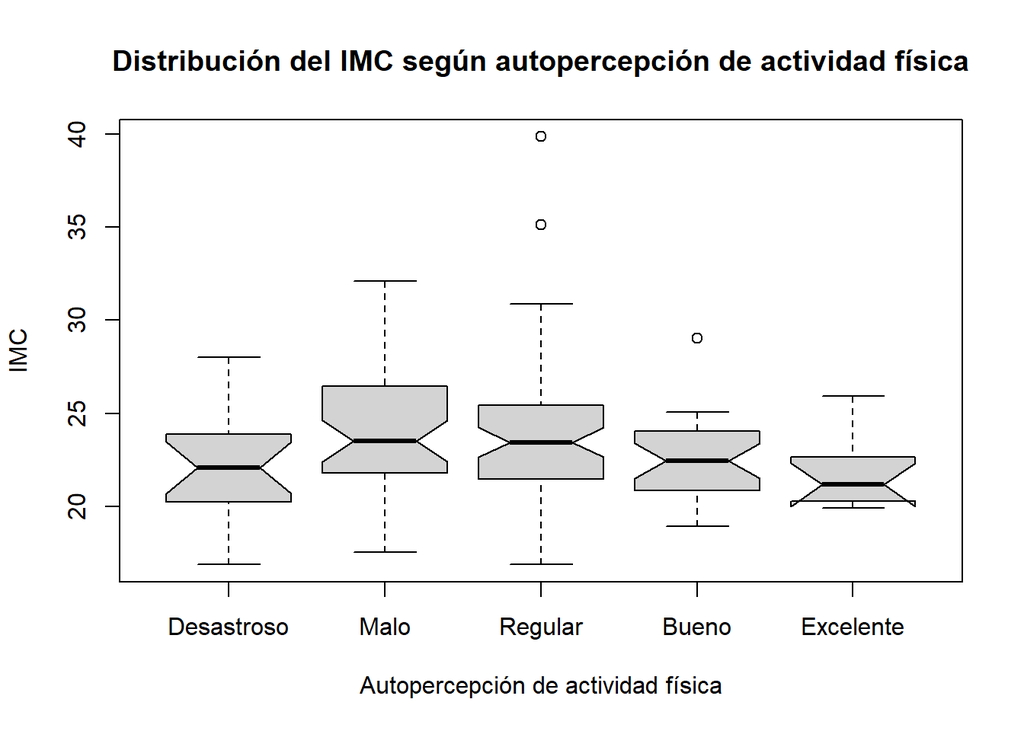

```r
cajas("Distribución del IMC según autopercepción de actividad física", "Autopercepción de actividad física", "IMC", IMC~Fisico, df)
```

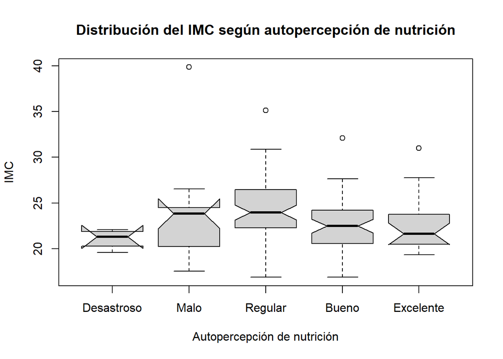

```r
cajas("Distribución del IMC según autopercepción de nutrición", "Autopercepción de nutrición", "IMC", IMC~Nutricion, df)
```

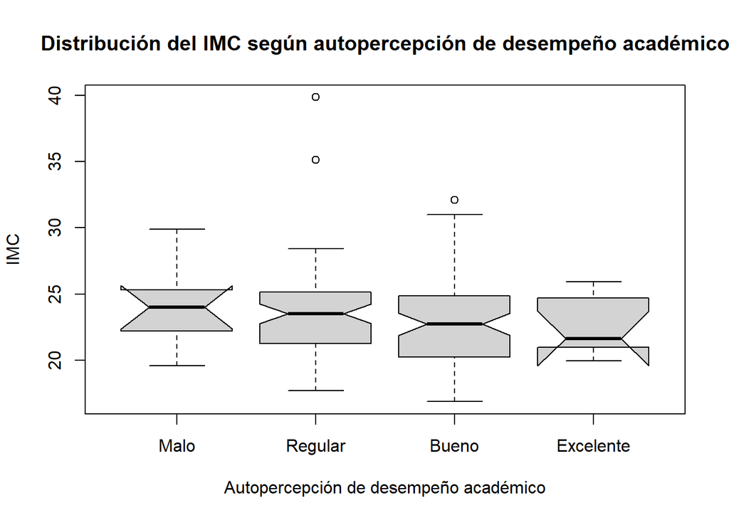

```r
cajas("Distribución del IMC según autopercepción de desempeño académico", "Autopercepción de desempeño académico", "IMC", IMC~Academico, df)
```

## VII.II. Relación lineal del IMC según una variable numérica

En esta subsección se busca determinar si alguna de las variables numéricas aparenta tener un impacto directo (lineal) en el IMC. Las más llamativas se evaluaran en etapas posteriores.

A continuación, se puede observar 4 valores de correlación. Se puede visualizar que ninguna de estas variables demuestra un evidente efecto lineal. Aquello lo sugiere el número; los valores de la correlación no se acercan ni a 1 ni a -1 lo suficiente.

```r
df = transform(df, IMC = apply(select(df, Peso, Estatura), 1, function(x) round2(x[1]/(x[2]/100)^2)))
df = transform(df, Ejercicio = rowSums(select(df, Anaerobico, Aerobico, Deporte)))
df = transform(df, Sedentarismo = rowSums(select(df, Video, Videojuego, RedSocial, Estudio, Trabajo, Clase)))
correlacion = function(x, y, xn, yn) paste("cor(", xn, ",", yn, ") : ", round2(cor(x, y)))
writeLines(c(
correlacion(df$Ejercicio, df$IMC, "Horas de ejercico/semana", "IMC"),
correlacion(df$Pickeo, df$IMC, "Cantidad de pickeos/semana", "IMC"),
correlacion(df$Delivery, df$IMC, "Cantidad de delivery/semana", "IMC"),
correlacion(df$Sedentarismo, df$IMC, "Horas de sedentarismo/semana", "IMC")
))
```

```
## cor( Horas de ejercico/semana , IMC ) :  0.08
## cor( Cantidad de pickeos/semana , IMC ) :  0.02
## cor( Cantidad de delivery/semana , IMC ) :  0.14
## cor( Horas de sedentarismo/semana , IMC ) :  0.11
```

A pesar de que ninguna parece estar fuertemente relacionada, cabe resaltar que las variables que más impacto parecen tener son el **sedentarismo y el pedido de delivery**. Ergo, se le dará mayor atención a estas variables y se analizará la estructura de los residuos, por si alguna muestra mayor indicios.

Por un lado, tenemos las gráficas que relacionan el IMC con el consumo de delivery a la semana. La gráfica número uno muestra una recta diagonal que indica la posible relación directamente proporcional (positiva) entre las variables; como complemento, se resaltan diferencia el sexo, pero este no parece importar. La segunda gráfica indica que los residuos podrían seguir un patrón no lineal, lo cual es negativo para este análisis. La segunda gráfica indica que los residuos siguen una distribución, casi a totalidad, normal. La tercera gráfica indica que no se cumple la homoestacidad entre los residuos; es decir, la varianza no permanece igual (los puntos están dispersos de manera sesgada en el espacio). La cuarta gráfica indica la existencia de valores que no siguen la tendencia de la mayoría y que modifican considerablemente la recta; en este escenario, solo existe un caso, pero que influye bastante (sobrepasa las lineas punteadas rojas, “distancia de Cook”). **Es síntesis, parece haber indicios suficientes para pensar que esta relación no es lineal.**

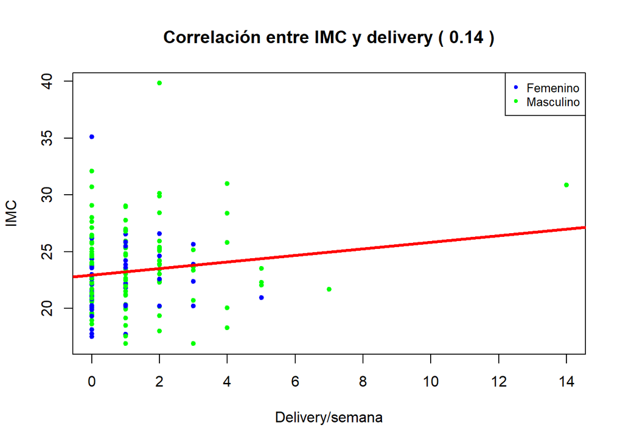

```r
dispersionc("Correlación entre IMC y delivery", "Delivery/semana", "IMC", df$Delivery, df$IMC, df$Sexo)
```

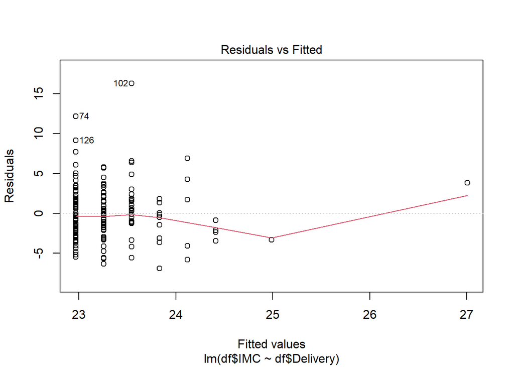

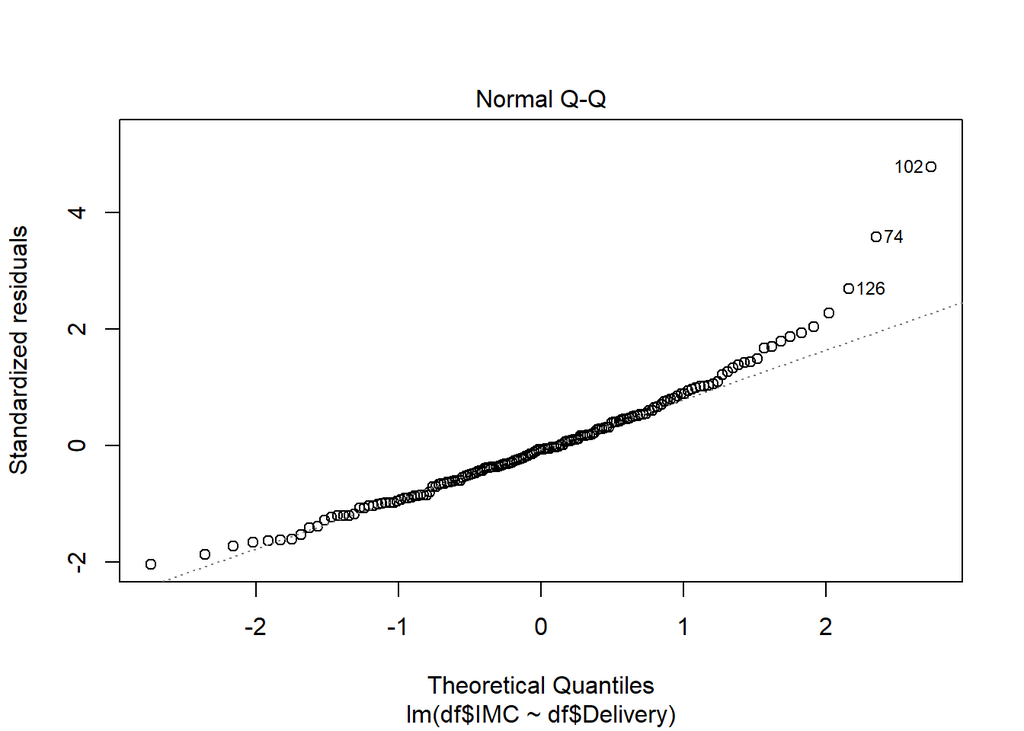

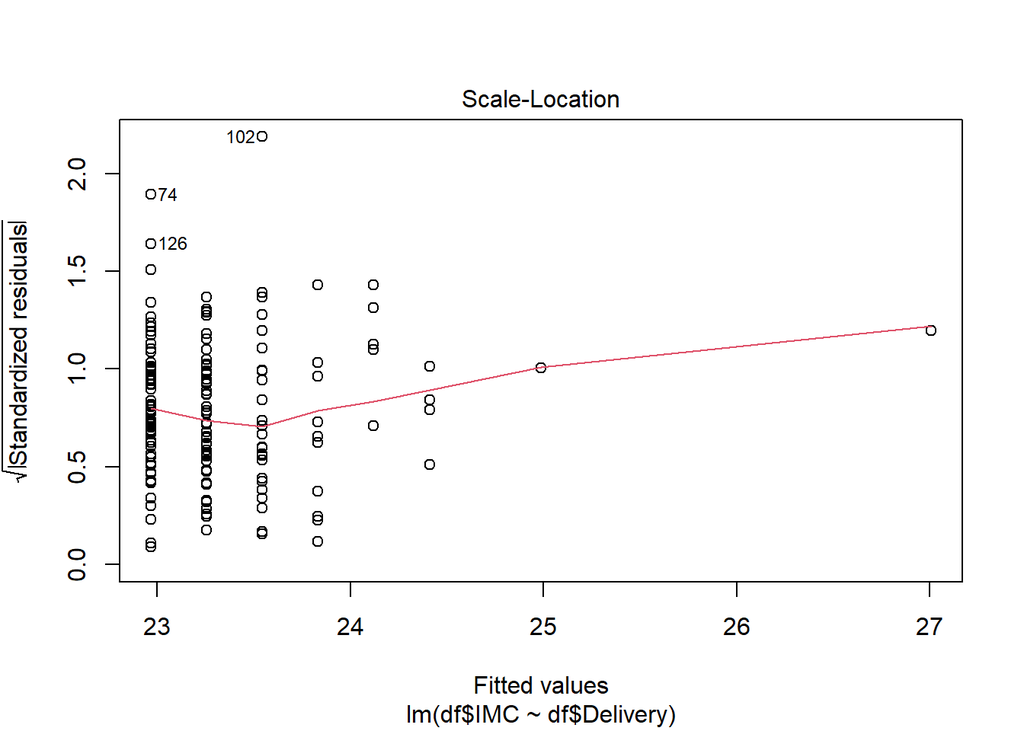

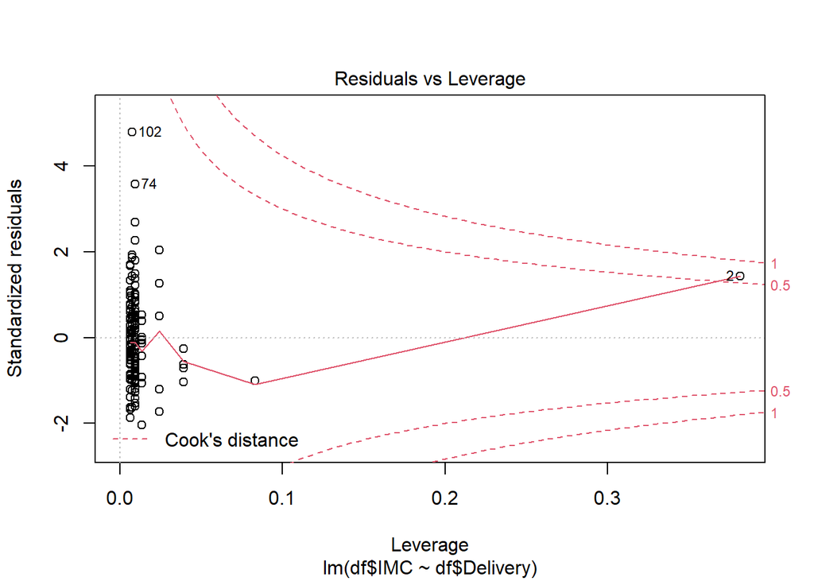

```r
plot(lm(df$IMC ~ df$Delivery))
```

Por otro lado, tenemos las gráficas que relacionan el IMC con las horas de sedentarismo a la semana. La gráfica número uno muestra una recta diagonal que indica la posible relación directamente proporcional (positiva) entre las variables; como complemento, se resaltan diferencia el sexo, pero este no parece importar. La segunda gráfica indica que los residuos podrían no seguir un patrón no lineal, lo cual es **positivo** para este análisis. La segunda gráfica indica que los residuos siguen una distribución, casi a totalidad, normal. La tercera gráfica indica que, en cierta medida, se cumple la homoestacidad entre los residuos; es decir, la varianza permanece igual (los puntos están dispersos de manera igualitaria en el espacio). La cuarta gráfica indica la existencia de valores que no siguen la tendencia de la mayoría y que modifican considerablemente la recta; en este escenario, no existe ni un caso realmente influyente (ninguno sobrepasa las lineas punteadas rojas, “distancia de Cook”). **Es síntesis, no parece haber indicios suficientes para pensar que esta relación no es lineal, es decir, podría serlo.**

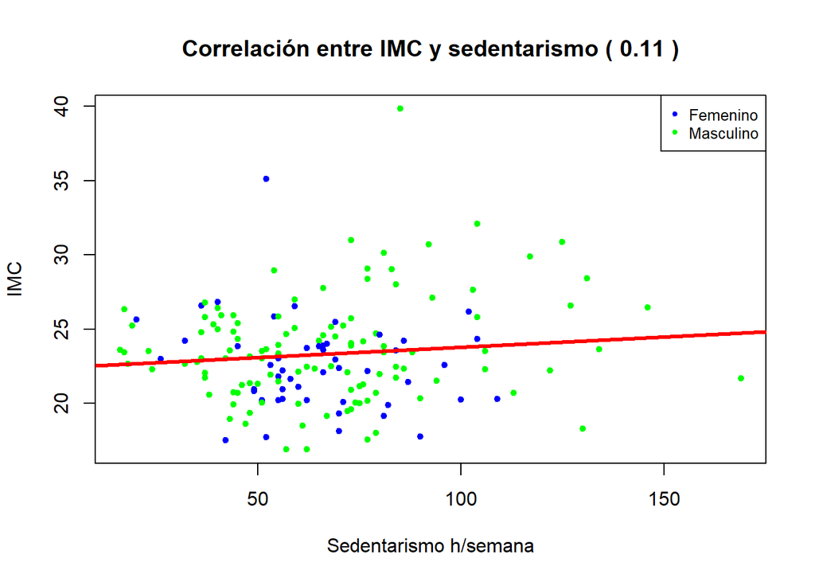

```r
dispersionc("Correlación entre IMC y sedentarismo", "Sedentarismo h/semana", "IMC", df$Sedentarismo, df$IMC, df$Sexo)
```

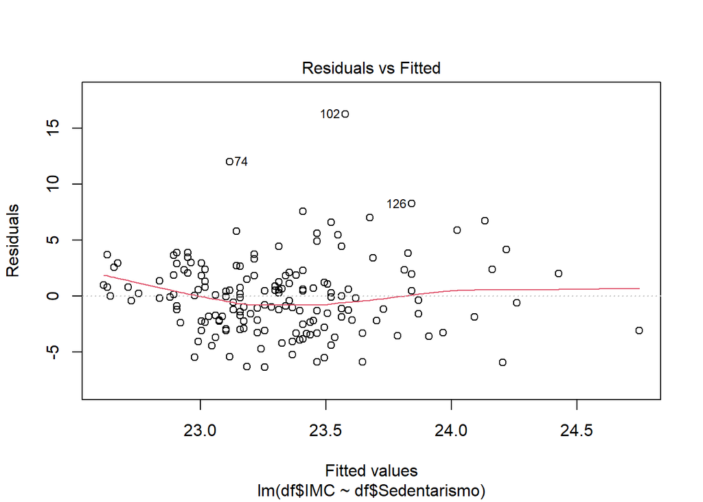

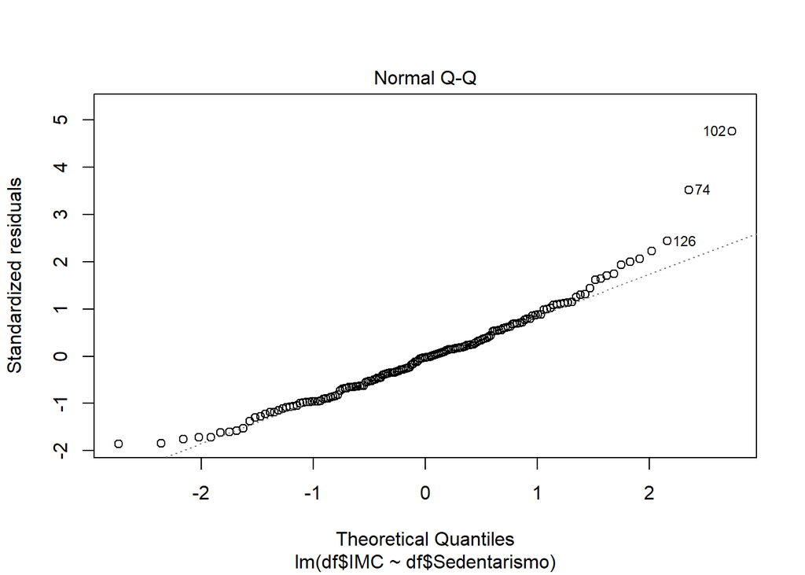

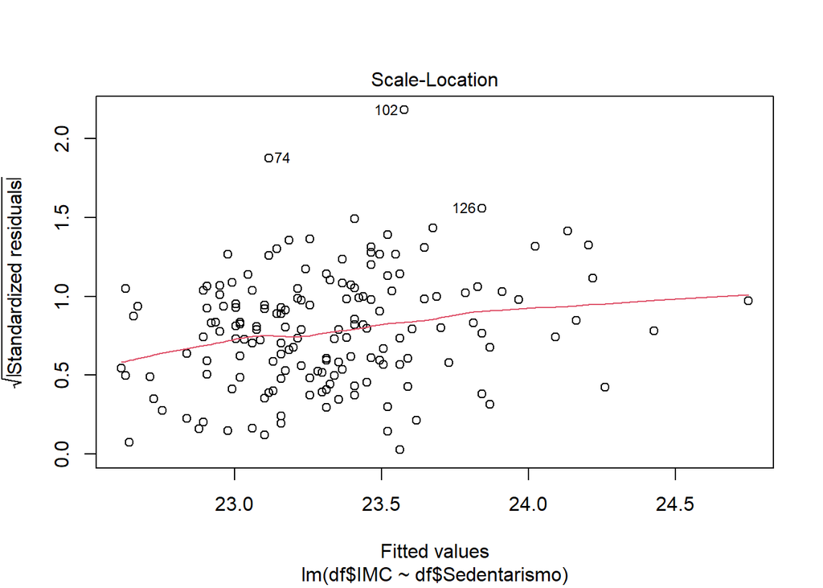

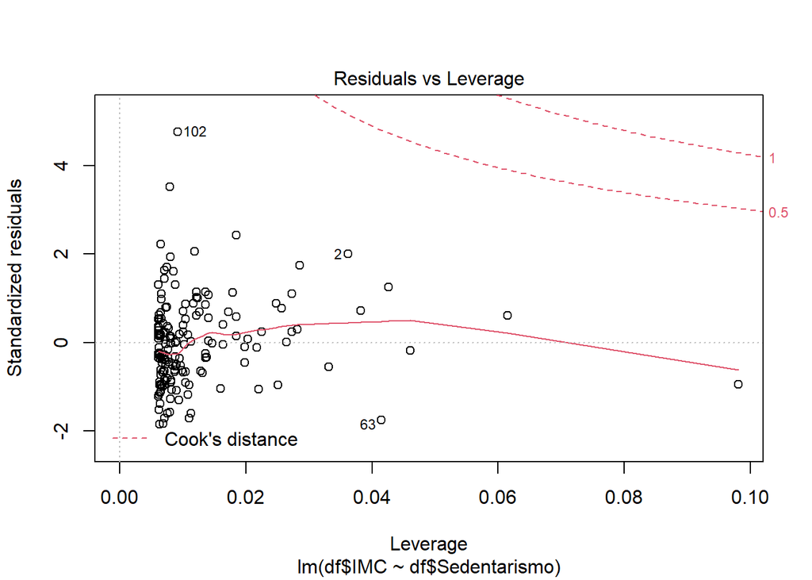

```r
plot(lm(df$IMC ~ df$Sedentarismo))
```

Aún si las correlaciones no son ideales para ambas, se optará por seguir con el análisis de la más prometedora en cuanto a residuos: el sedentarismo (explicado en el párrafo anterior). Por ello, en esta parte formulamos **1 hipótesis**: si el sedentarismo aumenta, el IMC, por lo general, también aumenta.

## VII.III. Distribución del diagnóstico del IMC según variables categóricas

En esta subsección se busca determinar la relación entre variables categóricas con los diagnósticos del IMC. Específicamente, se analiza la diferencia de probabilidades de pertenecer a cierto rango del IMC en base a las categorías de otra variable. Para ello, se dividirá el IMC por intervalos según los estándares mundiales y se emplearán gráficas de estilo mosaico en donde la variable dependiente será el IMC.

### VII.III.I. Categorización del IMC

Se decidió dividir el IMC en **dos** de los diagnósticos que define la Organización Mundial de la Salud: normopeso y sobrepeso **(World Health Organization, 1995)**. En la literatura se identifican más rangos, pero teniendo en cuenta el tamaño de muestra de este estudio, no se puede ser más específico. Por ende, el normopeso y el sobrepeso incluirán todas las demás categorías de cada extremo.

```r
#df = transform(df, C.IMC = cut(df$IMC, breaks = c(-Inf, 18.5, 25, 30, Inf), labels = c("Infra","Normo","Sobre", "Obeso")))
df = transform(df, C.IMC = cut(df$IMC, breaks = c(-Inf, 25, Inf), labels = c("Normo","Sobre")))
```

### VII.III.II. Mosaicos (x, y = Diagnóstico del IMC)

**Es imperativo resaltar que el análisis probabilístico de esta etapa no cuenta con un intervalo de confianza. Por ello, ninguna de las conclusiones son finales, sino solo indicios para formular hipótesis.**

**También es importante destacar que estas hipótesis no son ideales: son categóricas. No obstante, siguen representando distribuciones interesantes como para analizar posteriormente con mayor rigurosidad.**

En cuanto a la relación con el sexo, la muestra indica que es más probable encontrar sobrepeso dado el conjunto de hombres, que dado el conjunto de mujeres. Esta diferencia entre sexos, cercana al doble, permite formular la siguiente **hipótesis: el sexo y la categoría del IMC son variables dependientes para la población de la UTEC.**

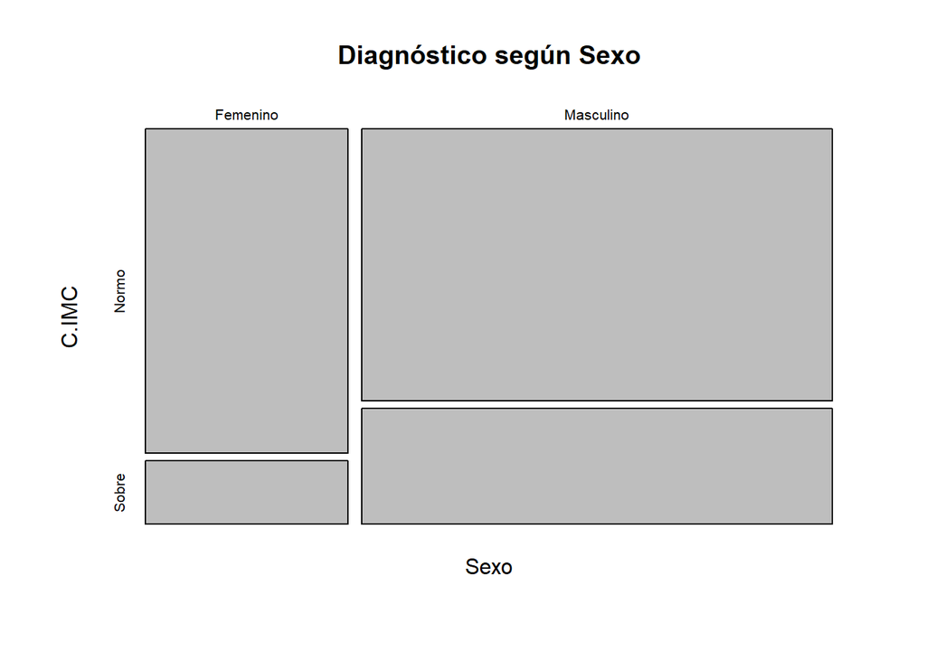

```r
IMC.segun("Sexo")
```

Para la relación con la actividad de ir al gimnasio o club para ejercitarse físicamente, la muestra indica que es igual de probable encontrar estudiantes con sobrepeso dado el conjunto de los que asisten a dichos lugares, que dado el otro conjunto. Esta similitud, permite formular la siguiente **hipótesis: ir al gimnasio o club para ejercitarse y la categoría del IMC son variables independientes para la población de la UTEC**.

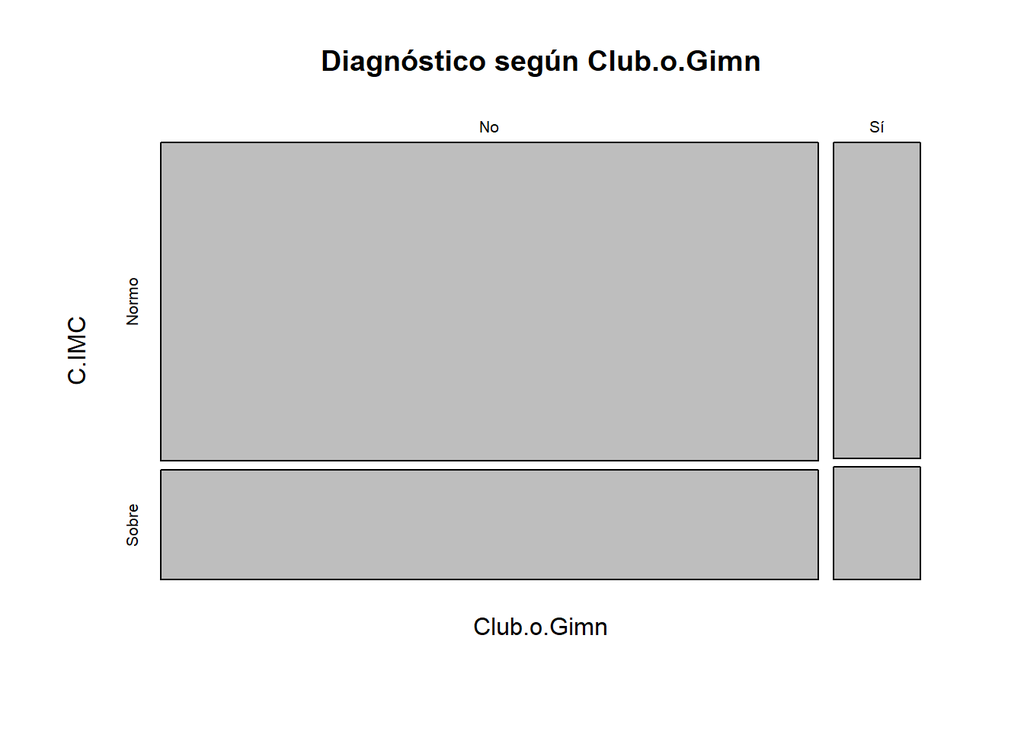

```r
df$Club.o.Gimn = ifelse(df$Club == "Sí" | df$Gimnasio == "Sí", "Sí", "No")
IMC.segun("Club.o.Gimn")
```

En relación a la relación con la porción de carbohidratos y proteínas que se come, la muestra indica que es más probable encontrar estudiantes con sobrepeso dado el conjunto de los que comen más proteínas, que dado el conjunto de los que comen casi igual cantidad de proteínas y carbohidratos. Esta diferencia entre los grupos, permite formular la siguiente **hipótesis: la proporción entre carbohidratos y proteínas que se come y el IMC son variables dependientes para la población de la UTEC.**

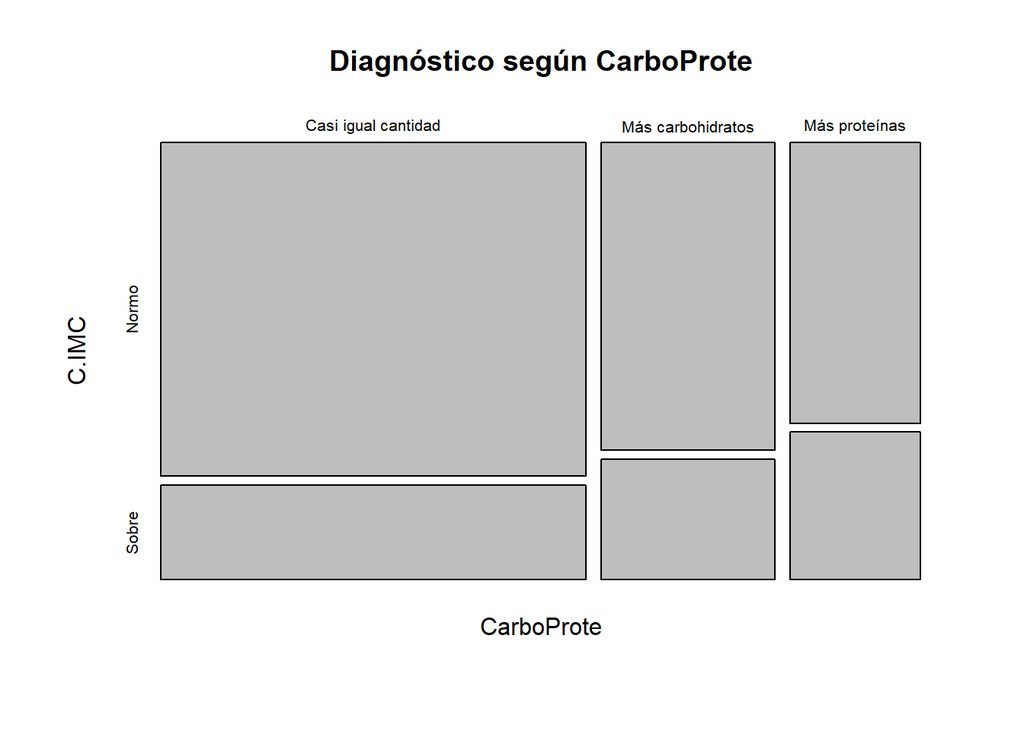

```r
IMC.segun("CarboProte")
```

# VIII. Pruebas de hipótesis

## VIII.I. Prueba de hipótesis sobre la distribución del sexo

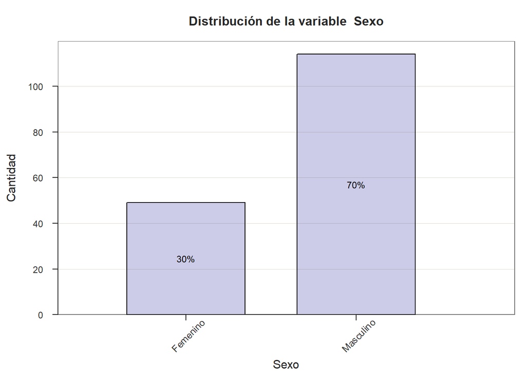

```r
resumen.categorico(Sexo)
```

Para a la variable sexo, se busca determinar si realmente se ve afectada por estudiar en la UTEC. Por ello, se plantea la siguiente **hipótesis nula: el sexo de una persona y estudiar en la UTEC son variables independientes.** Esto quiere decir que se espera una proporción similar a la del grupo de personas que van a la universidad, que, se puede asumir de manera aproximada, está compuesta por 50% de hombres y 50% de mujeres. En otras palabras, la hipótesis base espera que el porcentaje de hombres sea igual (o estadísticamente cercano) a 50%.

**H0: P(Hombre) == 50%**

**H1: P(Hombre) != 50%**

Con el fin de rechazar la hipótesis nula (decir que es diferente de 50%), se desea saber si la probabilidad de la composición actual de la muestra (70% hombres en 163 personas) es lo suficientemente baja. En este caso, se busca un 5% de significancia como mínimo y **no se prioriza ningún tipo de error (ni el 1, ni el 2)**.

Como probar la desigualdad implica **dos regiones de rechazo** (más pequeño o más grande), el umbral de cada región es 2.5%. Es decir, si la probabilidad de obtener más de 70% en una distribución normal **Norm(0.5, sqrt(0.7*(1-0.7)/163))** es menor a 2.5% entonces la hipótesis nula se rechaza.

```r
1-pprop(0.7, 0.5, 163)
```

```
## [1] 0.00000001258875
```

Como se puede observar, el p-valor obtenido denota una probabilidad que no solo cumple con el mínimo (sí es menor a 2.5%), sino que indica una frecuencia extremadamente baja. Ergo, si la muestra es representativa, **el sexo de una persona y estudiar en la UTEC no son variables independientes**.